# Final Project - Exhaustive Document

I am deciding that this is enough evidence for not redoing normalization with size factors specific to just the TF genes. I will adjust my p-values in my transcription factor DESeq2 object to just reflect the sample size of the TF gene counts, however. This will happen automatically through the results() function, setting Independent Filtering = TRUE.

```r
all_results <- results(dds_yamanaka, contrast=c("condition", "96 Hours Post-OSKM", "Control"))
```

```r
# Remove version numbers from the rownames
rownames(dds_yamanaka) <- gsub("\\..*", "", rownames(dds_yamanaka))

# Subset the results to include only transcription factors
tf_results <- all_results[rownames(all_results) %in% confirmed_tfs,]
```

I originally used Benjamini-Hochberg, and while the Yamanaka factors are renownedly transcriptionally transformative, and I thus expect highly differential expression, My general prior is not quite so high as 50% of TFs showing significantly differential expression. Especially given the fact that this is not a case and control, per se, but progression through a condition.

```r
# Recompute p-adjustment only for the subset of transcription factors
tf_results$padj <- p.adjust(tf_results$pvalue, method = "holm")
```

```r
# Print the top rows to check significant transcription factors
head(tf_results[order(tf_results$padj),])
```

```
## log2 fold change (MLE): condition 96 Hours Post-OSKM vs Control
## Wald test p-value: condition 96 Hours Post-OSKM vs Control
## DataFrame with 6 rows and 6 columns
##                  baseMean log2FoldChange     lfcSE      stat      pvalue
##                 <numeric>      <numeric> <numeric> <numeric>   <numeric>
## ENSG00000204531 43317.764       11.84677  0.270817   43.7445 0.00000e+00
## ENSG00000136826 21747.777        5.95566  0.282550   21.0782 1.26004e-98
## ENSG00000181449 11953.218       13.26263  0.639089   20.7524 1.16631e-95
## ENSG00000185507  1337.839        3.69423  0.192988   19.1422 1.12322e-81
## ENSG00000188313  2633.627        2.90243  0.179683   16.1531 1.08033e-58
## ENSG00000151090   239.281        5.29659  0.335814   15.7724 4.81809e-56
##                        padj
##                   <numeric>
## ENSG00000204531 0.00000e+00
## ENSG00000136826 1.95054e-95
## ENSG00000181449 1.80428e-92
## ENSG00000185507 1.73650e-78
## ENSG00000188313 1.66911e-55
## ENSG00000151090 7.43913e-53
```

I will illustrate some overall differential gene expression analysis of the two conditions, before delving into specific GO term enrichment analysis

```r
summary(tf_results)
```

```
##
## out of 1549 with nonzero total read count
## adjusted p-value < 0.1
## LFC > 0 (up)       : 172, 11%
## LFC < 0 (down)     : 123, 7.9%
## outliers [1]       : 0, 0%
## low counts [2]     : 0, 0%
## (mean count < 1)
## [1] see 'cooksCutoff' argument of ?results
## [2] see 'independentFiltering' argument of ?results
```

```r
length(tf_results$padj)
```

```
## [1] 1549
```

```r
table(tf_results$padj < 0.05)
```

```
##
## FALSE  TRUE
##  1275   274
```

Even with the relative stringency of the Holm-Bonferroni correction, we are still observing 17.7% of our TFs as being significantly differentially expressed.

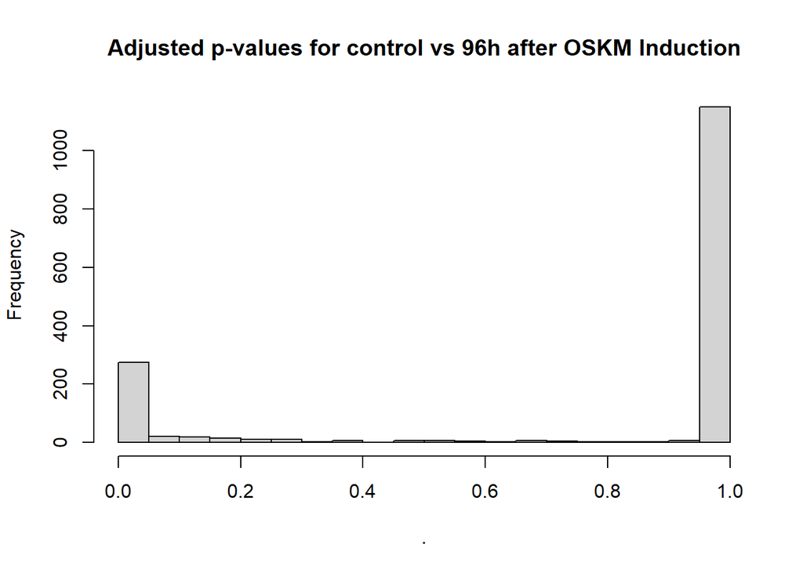

```r
tf_results$padj %>%
hist(breaks=19, main="Adjusted p-values for control vs 96h after OSKM Induction")
```

```r
tf_results_sorted <- tf_results %>% `[`(order(.$padj),)

library(org.Hs.eg.db)
```

```r
all_genes <- keys(org.Hs.eg.db, keytype = "ENSEMBL")
symbols <- mapIds(org.Hs.eg.db, keys = all_genes, column = "SYMBOL", keytype = "ENSEMBL", multiVals = "first")
# Also, retrieve ORF names (if available)
orfs <- mapIds(org.Hs.eg.db, keys = all_genes, column = "REFSEQ", keytype = "ENSEMBL", multiVals = "first")
# Add gene symbols or use ENSEMBL ID as fallback
tf_results_sorted$gene_symbol_or_ORF <- ifelse(!is.na(symbols[rownames(tf_results_sorted)]), symbols[rownames(tf_results_sorted)], orfs[rownames(tf_results_sorted)])
tf_results_sorted$ORF <- orfs[rownames(tf_results_sorted)]  # Add ORFs as a separate column

head(tf_results_sorted)
```

```
## log2 fold change (MLE): condition 96 Hours Post-OSKM vs Control
## Wald test p-value: condition 96 Hours Post-OSKM vs Control
## DataFrame with 6 rows and 8 columns
##                  baseMean log2FoldChange     lfcSE      stat      pvalue
##                 <numeric>      <numeric> <numeric> <numeric>   <numeric>
## ENSG00000204531 43317.764       11.84677  0.270817   43.7445 0.00000e+00
## ENSG00000136826 21747.777        5.95566  0.282550   21.0782 1.26004e-98
## ENSG00000181449 11953.218       13.26263  0.639089   20.7524 1.16631e-95
## ENSG00000185507  1337.839        3.69423  0.192988   19.1422 1.12322e-81
## ENSG00000188313  2633.627        2.90243  0.179683   16.1531 1.08033e-58
## ENSG00000151090   239.281        5.29659  0.335814   15.7724 4.81809e-56
##                        padj gene_symbol_or_ORF          ORF
##                   <numeric>        <character>  <character>
## ENSG00000204531 0.00000e+00             POU5F1 NM_001173531
## ENSG00000136826 1.95054e-95               KLF4 NM_001314052
## ENSG00000181449 1.80428e-92               SOX2    NM_003106
## ENSG00000185507 1.73650e-78               IRF7    NM_001572
## ENSG00000188313 1.66911e-55             PLSCR1 NM_001363872
## ENSG00000151090 7.43913e-53               THRB    NM_000461
```

I checked the number of coefficients, and found intercept and my condition comparison.

```r
shrunk_tf_results = lfcShrink(dds_yamanaka, coef=2, type = "apeglm")
```

```
## using 'apeglm' for LFC shrinkage. If used in published research, please cite:
##     Zhu, A., Ibrahim, J.G., Love, M.I. (2018) Heavy-tailed prior distributions for
##     sequence count data: removing the noise and preserving large differences.
##     Bioinformatics. https://doi.org/10.1093/bioinformatics/bty895
```

```r
# Subset the results to include only transcription factors
shrunk_tf_results <- all_results[rownames(shrunk_tf_results) %in% confirmed_tfs,]

# Recompute p-adjustment only for the subset of transcription factors
shrunk_tf_results$padj <- p.adjust(shrunk_tf_results$pvalue, method = "holm")

# Add gene symbols or use ENSEMBL ID as fallback
shrunk_tf_results$gene_symbol_or_ORF <- ifelse(!is.na(symbols[rownames(shrunk_tf_results)]), symbols[rownames(shrunk_tf_results)], rownames(shrunk_tf_results))

# Sort shrunk results
shrunk_tf_results_sorted <- shrunk_tf_results %>% `[`(order(.$padj),)

shrunk_tf_results_sorted$gene_symbol_or_ORF <- ifelse(!is.na(symbols[rownames(shrunk_tf_results_sorted)]), symbols[rownames(shrunk_tf_results_sorted)], orfs[rownames(shrunk_tf_results_sorted)])
shrunk_tf_results_sorted$ORF <- orfs[rownames(shrunk_tf_results_sorted)]  # Add ORFs as a separate column

head(shrunk_tf_results_sorted)
```

```
## log2 fold change (MLE): condition 96 Hours Post-OSKM vs Control
## Wald test p-value: condition 96 Hours Post-OSKM vs Control
## DataFrame with 6 rows and 8 columns
##                  baseMean log2FoldChange     lfcSE      stat      pvalue
##                 <numeric>      <numeric> <numeric> <numeric>   <numeric>
## ENSG00000204531 43317.764       11.84677  0.270817   43.7445 0.00000e+00
## ENSG00000136826 21747.777        5.95566  0.282550   21.0782 1.26004e-98
## ENSG00000181449 11953.218       13.26263  0.639089   20.7524 1.16631e-95
## ENSG00000185507  1337.839        3.69423  0.192988   19.1422 1.12322e-81
## ENSG00000188313  2633.627        2.90243  0.179683   16.1531 1.08033e-58
## ENSG00000151090   239.281        5.29659  0.335814   15.7724 4.81809e-56
##                        padj gene_symbol_or_ORF          ORF
##                   <numeric>        <character>  <character>
## ENSG00000204531 0.00000e+00             POU5F1 NM_001173531
## ENSG00000136826 1.95054e-95               KLF4 NM_001314052
## ENSG00000181449 1.80428e-92               SOX2    NM_003106
## ENSG00000185507 1.73650e-78               IRF7    NM_001572
## ENSG00000188313 1.66911e-55             PLSCR1 NM_001363872
## ENSG00000151090 7.43913e-53               THRB    NM_000461
```

We see the expected pattern manifesting, finding more differentially expressed genes as we move towards the right hand of the plot, where we find more strongly expressed genes.

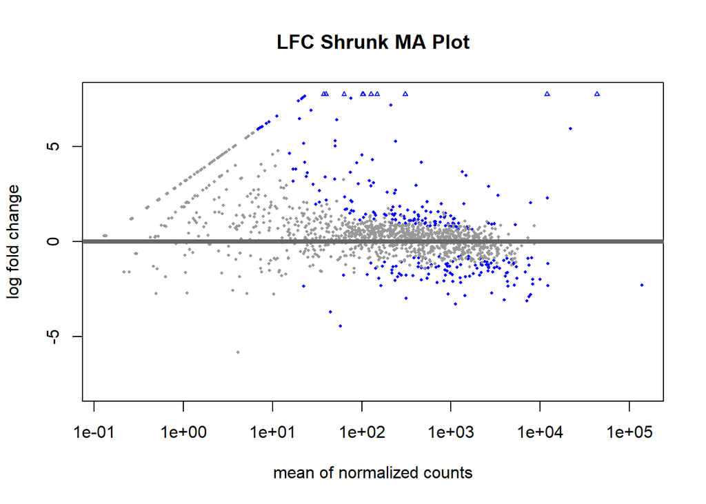

```r
plotMA(shrunk_tf_results_sorted, alpha=0.05,
main="LFC Shrunk MA Plot")
```

```r
library(EnhancedVolcano)
```

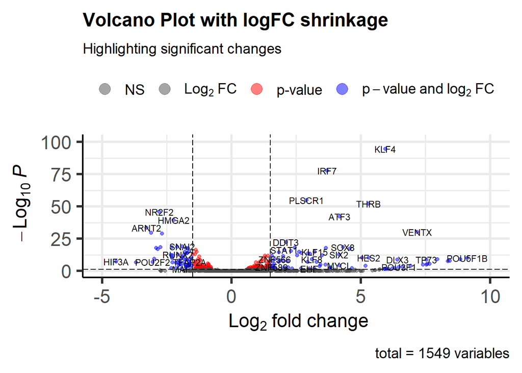

```r
# Handling p-values of 0 by adjusting to a small number if necessary
shrunk_tf_results_sorted$padj[shrunk_tf_results_sorted$padj == 0] <- min(shrunk_tf_results_sorted$padj[shrunk_tf_results_sorted$padj > 0], na.rm = TRUE) * 10^-1

# Updated EnhancedVolcano call
vp2 <- EnhancedVolcano(shrunk_tf_results_sorted,
                       lab = shrunk_tf_results_sorted$gene_symbol_or_ORF,
                       x = 'log2FoldChange',
                       y = 'padj',
                       pCutoff = 0.05,
                       FCcutoff = 1.5,  # Log2 fold change cutoff
                       title = "Volcano Plot with logFC shrinkage",
                       subtitle = "Highlighting significant changes",
                       col=c('grey30', 'grey30', 'red', 'blue'),  # Colors: non-significant, significant
                       labSize = 3.0,
                       pointSize = c(1.5),  # Ensure this matches the data size; might need adjustment
                       xlim = c(-5, 10))

# Print the plot
print(vp2)
```

```r
# Selecting the top ten most significant genes
top_ten_genes <- head(shrunk_tf_results_sorted, 10)

# Displaying the gene symbols, log fold changes, and adjusted p-values of the top ten genes
top_ten_summary <- top_ten_genes[, c("gene_symbol_or_ORF", "log2FoldChange", "padj")]
print(top_ten_summary)
```

```
## log2 fold change (MLE): condition 96 Hours Post-OSKM vs Control
##
## DataFrame with 10 rows and 3 columns
##                 gene_symbol_or_ORF log2FoldChange        padj
##                        <character>      <numeric>   <numeric>
## ENSG00000204531             POU5F1       11.84677 1.95054e-96
## ENSG00000136826               KLF4        5.95566 1.95054e-95
## ENSG00000181449               SOX2       13.26263 1.80428e-92
## ENSG00000185507               IRF7        3.69423 1.73650e-78
## ENSG00000188313             PLSCR1        2.90243 1.66911e-55
## ENSG00000151090               THRB        5.29659 7.43913e-53
## ENSG00000185551              NR2F2       -2.79261 1.56144e-46
## ENSG00000162772               ATF3        4.17905 7.16016e-43
## ENSG00000149948              HMGA2       -2.23856 3.17670e-40
## ENSG00000172379              ARNT2       -3.28282 3.69143e-34
```

I plot the normalized counts of these top ten TF genes for my two conditions alongside one another, to get a sense of absolute expression values beyond LFC.

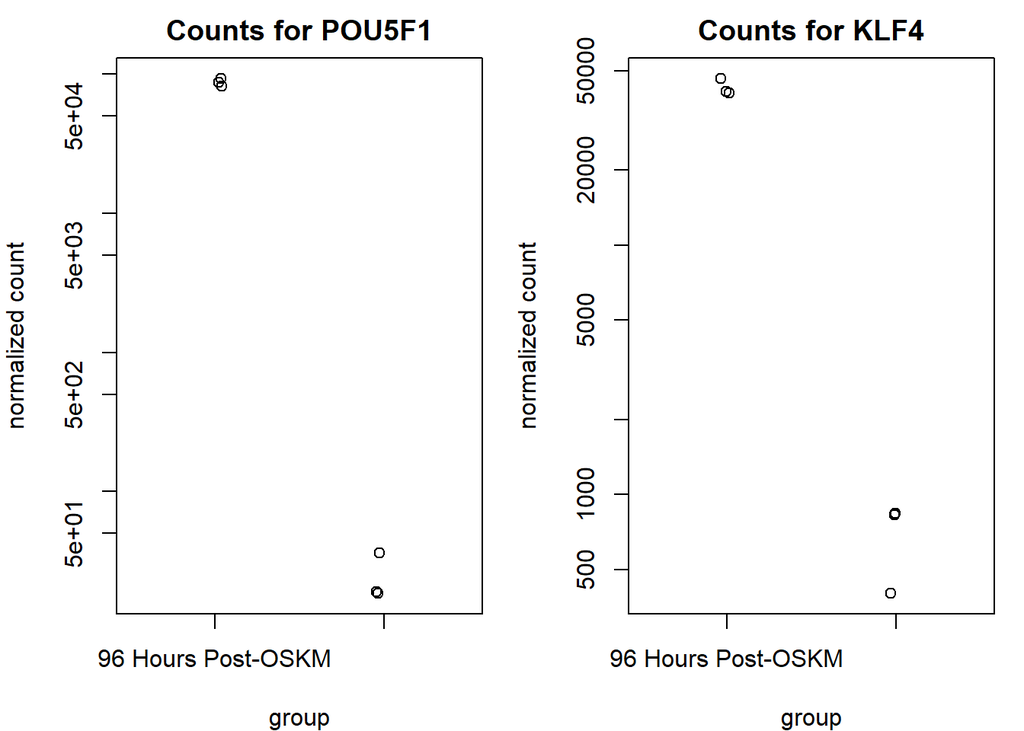

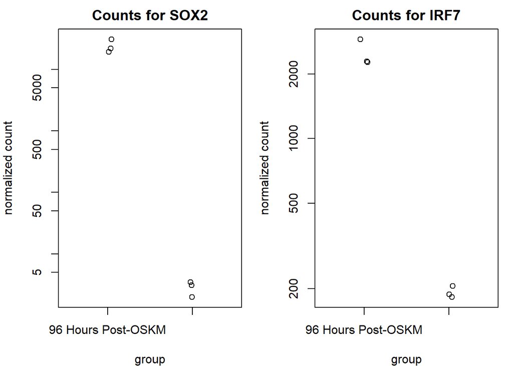

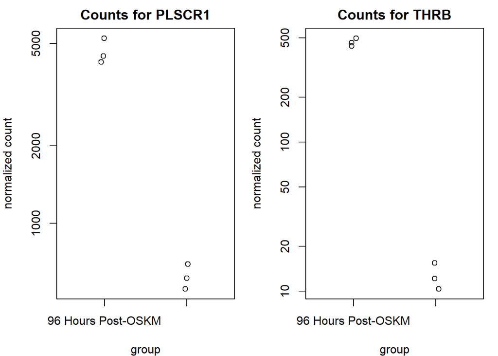

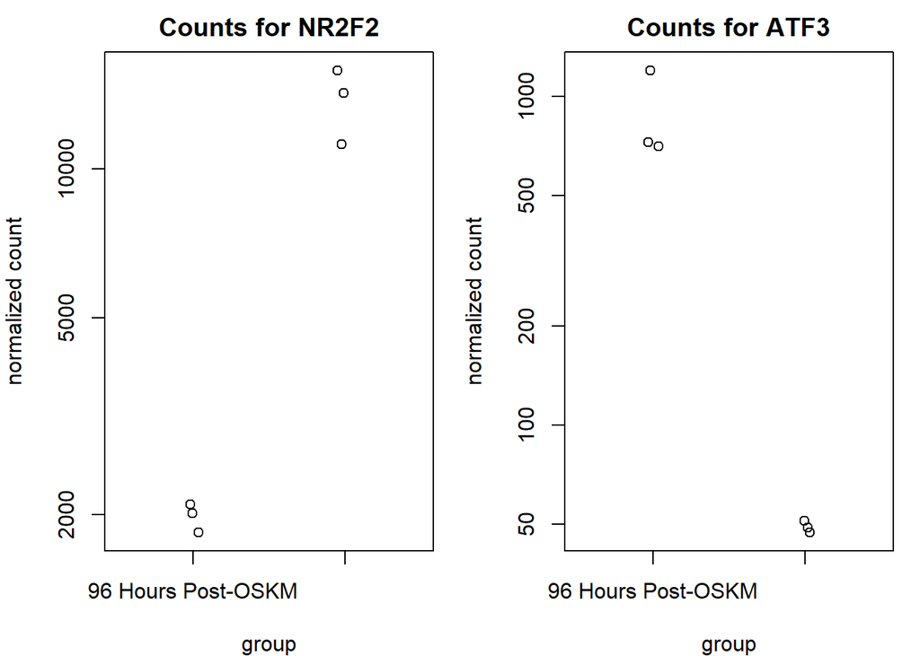

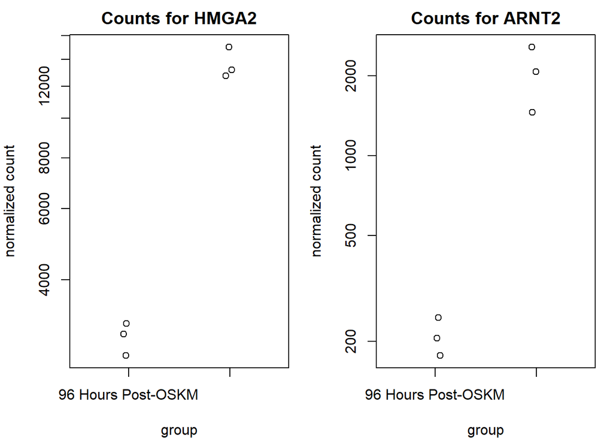

```r
# Setup plotting parameters
par(mfrow=c(1, 2))  # 1 row, 2 columns
par(mar=c(4, 4, 2, 1))  # Margins on the bottom, left, top, and right of each plot

gene_ids = rownames(top_ten_genes)
# Iterate over gene_ids, which should correspond to rownames in top_ten_genes
for (i in seq_along(gene_ids)) {
  gene_id <- gene_ids[i]
  gene_symbol <- top_ten_genes$gene_symbol_or_ORF[gene_id]  # Correct indexing

  plot_title <- paste("Counts for", gene_symbol)

  # Plot counts for this gene
  plotCounts(dds_yamanaka, gene=gene_id, intgroup="condition", normalized=TRUE, main=plot_title)

  # Check if it's time to move to a new page after every two plots
  if (i %% 2 == 0 || i == length(gene_ids)) {
    # This resets the plotting parameters and is necessary only if plotting to a PDF or similar
    # dev.new()  # Uncomment for multi-page PDFs
  }
}
```

```r
# Assuming shrunk_tf_results_sorted is already sorted by significance
# Filter for significant results and separate positives and negatives
significant_genes <- shrunk_tf_results_sorted[shrunk_tf_results_sorted$padj < 0.05, ]

# Top ten positive log2 fold changes
top_ten_positive <- head(significant_genes[order(significant_genes$log2FoldChange, decreasing = TRUE),], 10)

# Top ten negative log2 fold changes
top_ten_negative <- head(significant_genes[order(significant_genes$log2FoldChange, decreasing = FALSE),], 10)

# Combine the lists for plotting
top_genes_combined <- rbind(top_ten_positive, top_ten_negative)
```

```r
# Setup the plotting parameters for five plots per display
par(mfrow=c(1, 5))  # 1 row, 5 columns

# Iterate over the gene list and plot normalized counts
plot_gene_counts <- function(genes_df) {
  for (i in 1:nrow(genes_df)) {
    gene_id <- rownames(genes_df)[i]
    gene_symbol <- genes_df$gene_symbol_or_ORF[i]
    direction <- ifelse(genes_df$log2FoldChange[i] > 0, "Upregulated", "Downregulated")

    plot_title <- paste(direction, gene_symbol, sep=": ")

    # Plot counts for this gene
    plotCounts(dds_yamanaka, gene=gene_id, intgroup="condition", normalized=TRUE, main=plot_title)

    # Refresh the plotting device after every five plots or at the end of the list
    if (i %% 5 == 0 || i == nrow(genes_df)) {
      # This ensures a new image starts if there are more genes to plot
      if (i != nrow(genes_df)) {

      }
    }
  }
}

# Run the plotting function for the top ten positive log fold changes
cat("Displaying Upregulated Transcription Factors:\n")
```

```
## Displaying Upregulated Transcription Factors:
```

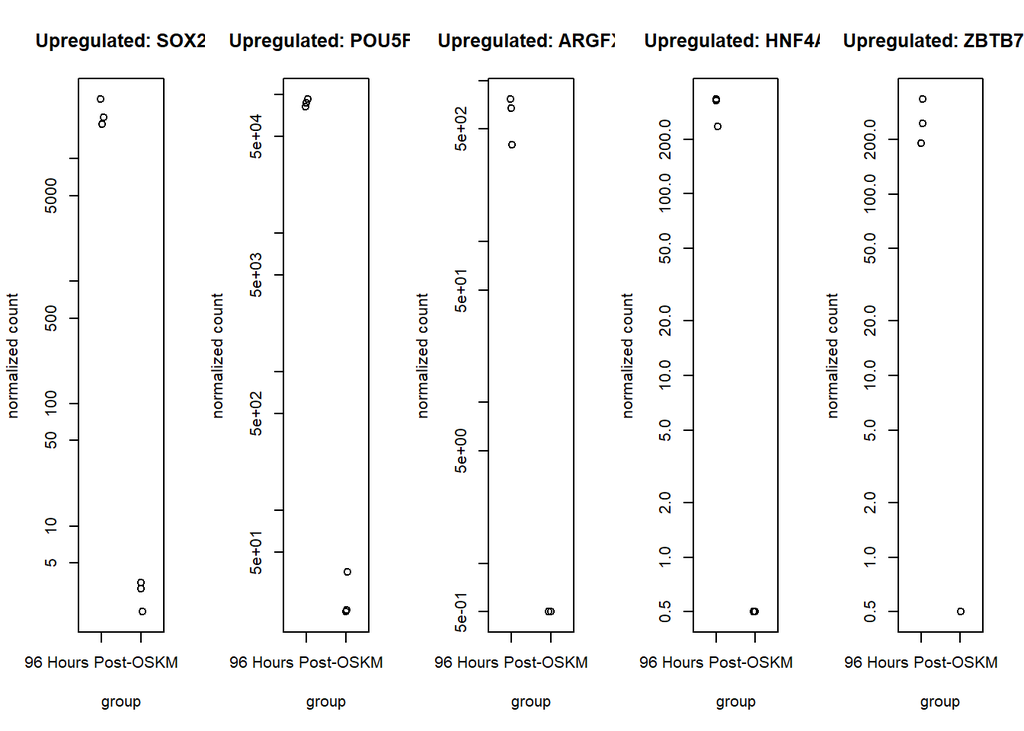

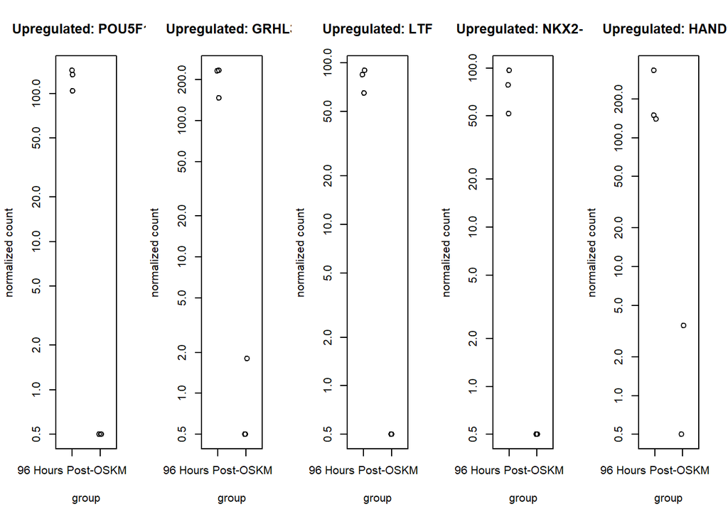

```r
plot_gene_counts(top_ten_positive)
```

```r
par(mfrow=c(1, 5))  # Setup for new series of plots
cat("Displaying Downregulated Transcription Factors:\n")
```

```
## Displaying Downregulated Transcription Factors:
```

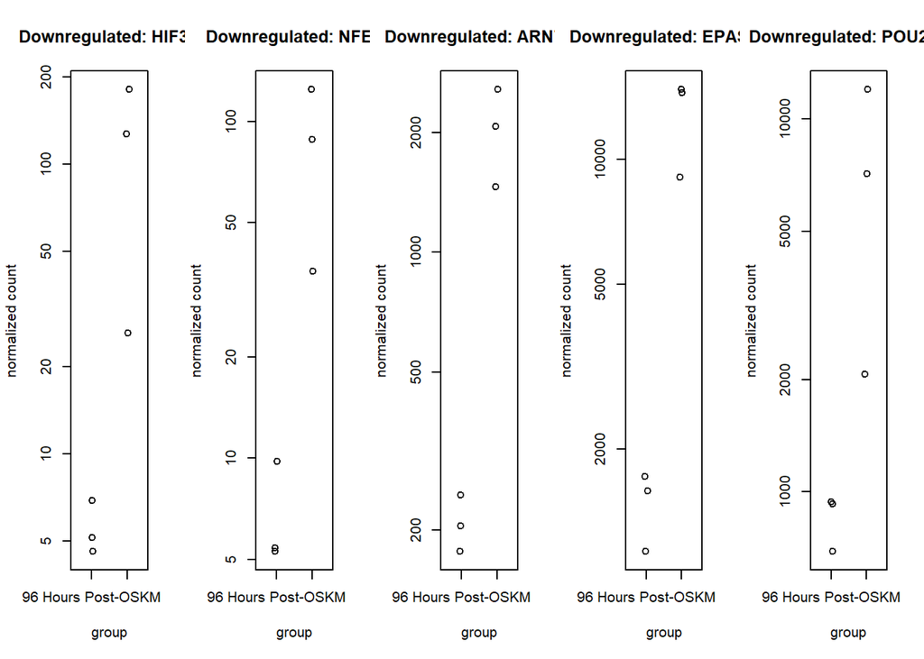

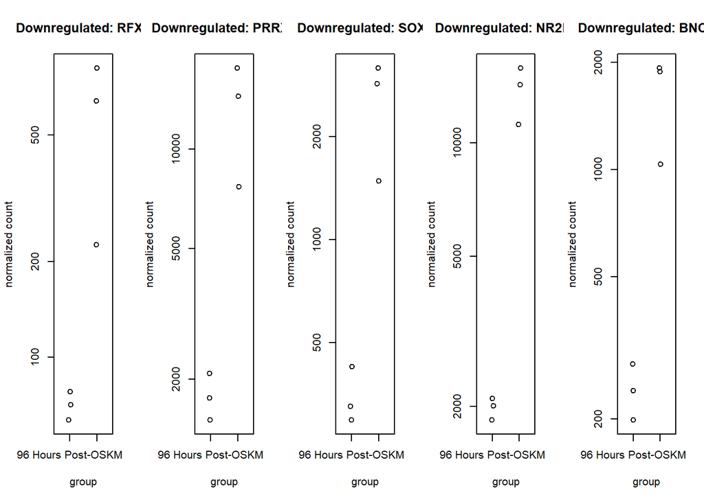

```r
plot_gene_counts(top_ten_negative)
```

By plotting the top ten downregulated TF genes from the control to the 96 hour condition and the top ten positive, I didn’t mean to equate the overall impression of TF up-versus-down-regulation we see in this comparison. As made clear in both the volcano plot and the list of the top ten overall most significantly differentially enriched genes, there are more cases of high L2FC, high significance genes than low L2FC, high significance genes. However, I’d like to assess gene ontology enrichment for the two categories, to see if we can get a general impression of - assuming that we are seeing signal and not merely the noise of TF’s erratic transcriptomic patterning - what cellular processes the Yamanaka factors are promoting/inhibiting.

I will also make some GO visualizations for the entire set of positive L2FC, statistically significant, 96-hour-sample-enriched genes, and the entire set of negative L2FC, statistically signficant, untreated_fibroblast-enriched genes.

I begin with the larger sets.

```r
library(dplyr)
library(clusterProfiler)
```

```r
library(org.Hs.eg.db)
library(enrichplot)
library(ggplot2)

# Convert DESeqResults to a standard data frame first
shrunk_tf_results_df <- as.data.frame(shrunk_tf_results_sorted)

# Extract all significant genes with positive and negative log2FoldChanges
all_positive_genes <- shrunk_tf_results_df %>%
                      filter(padj < 0.05 & log2FoldChange > 0) %>%
                      pull(gene_symbol_or_ORF)

all_negative_genes <- shrunk_tf_results_df %>%
                      filter(padj < 0.05 & log2FoldChange < 0) %>%
                      pull(gene_symbol_or_ORF)

# Convert gene symbols to ENTREZ IDs (if your data uses gene symbols)
positive_entrez <- bitr(all_positive_genes, fromType="SYMBOL", toType="ENTREZID", OrgDb="org.Hs.eg.db")
negative_entrez <- bitr(all_negative_genes, fromType="SYMBOL", toType="ENTREZID", OrgDb="org.Hs.eg.db")
# Perform GO enrichment analysis
ego_pos <- enrichGO(gene          = positive_entrez$ENTREZID,
                    OrgDb         = org.Hs.eg.db,
                    keyType       = "ENTREZID",
                    ont           = "BP",
                    pAdjustMethod = "holm",
                    qvalueCutoff  = 0.05)

ego_neg <- enrichGO(gene          = negative_entrez$ENTREZID,
                    OrgDb         = org.Hs.eg.db,
                    keyType       = "ENTREZID",
                    ont           = "BP",
                    pAdjustMethod = "holm",
                    qvalueCutoff  = 0.05)
```

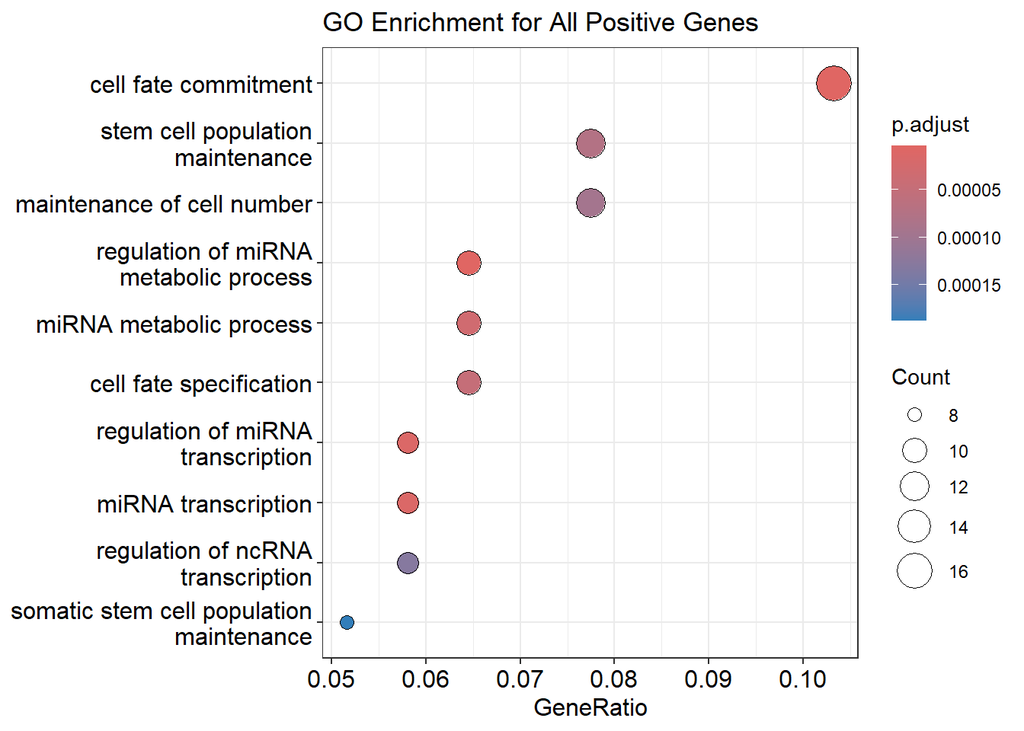

```r
# Visualize with a dotplot
dotplot(ego_pos) + ggtitle("GO Enrichment for All Positive Genes")
```

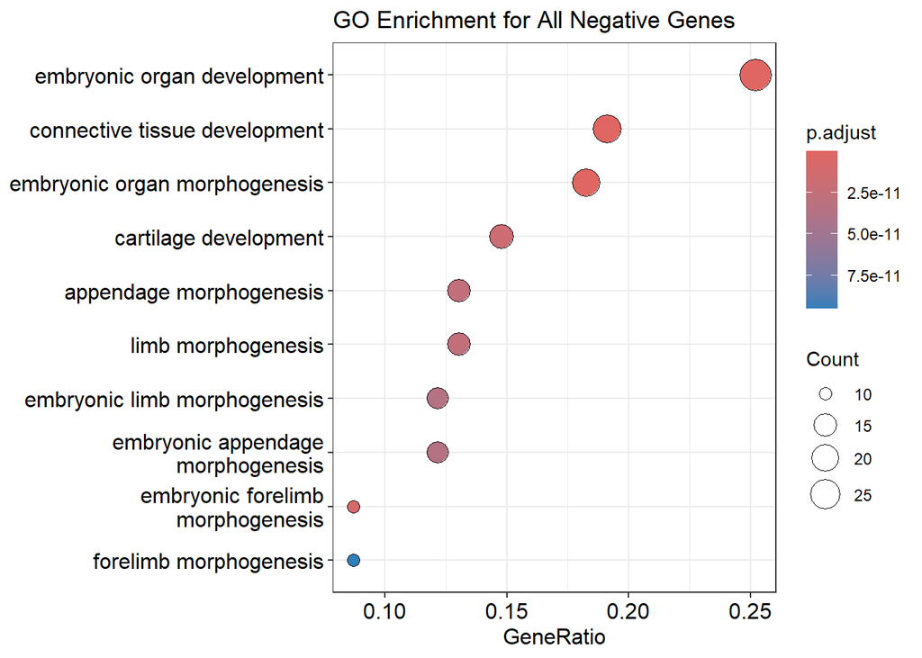

```r
dotplot(ego_neg) + ggtitle("GO Enrichment for All Negative Genes")
```

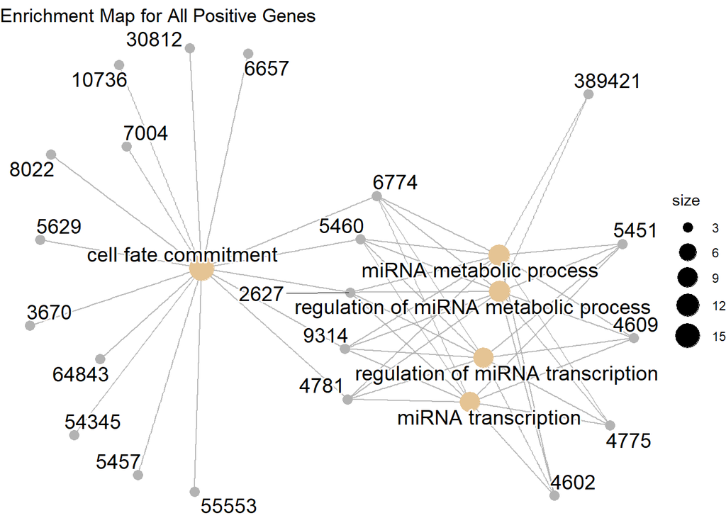

```r
# Visualize with a cnetplot
cnetplot(ego_pos, foldChange=positive_entrez$log2FoldChange) + ggtitle("Enrichment Map for All Positive Genes")
```

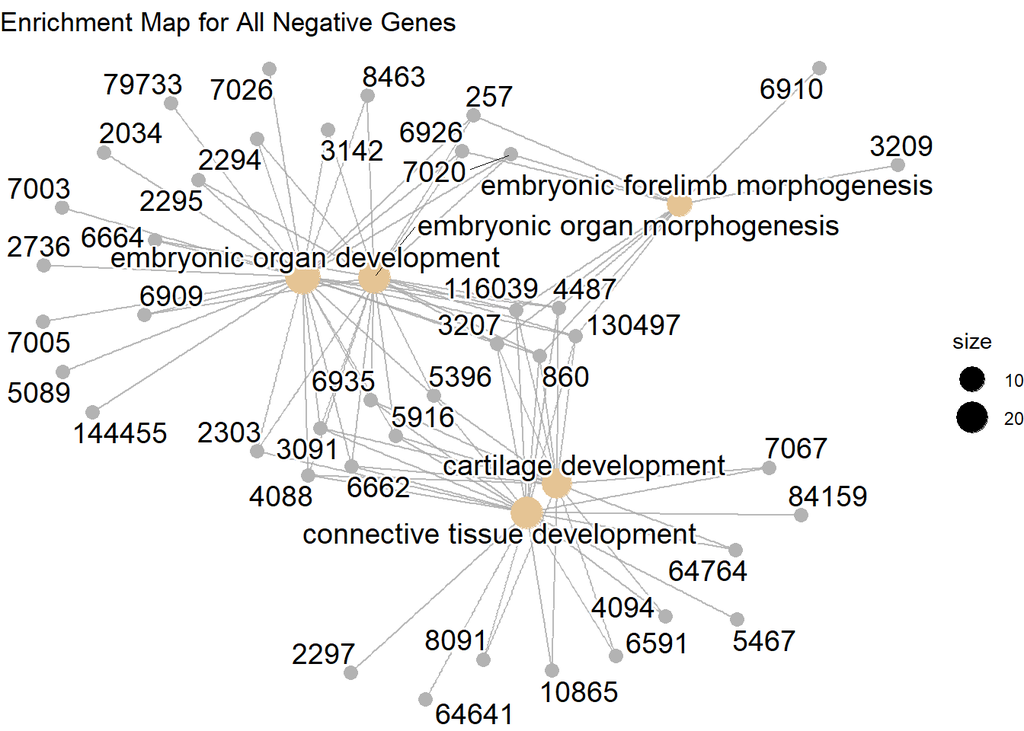

```r
cnetplot(ego_neg, foldChange=negative_entrez$log2FoldChange) + ggtitle("Enrichment Map for All Negative Genes")
```

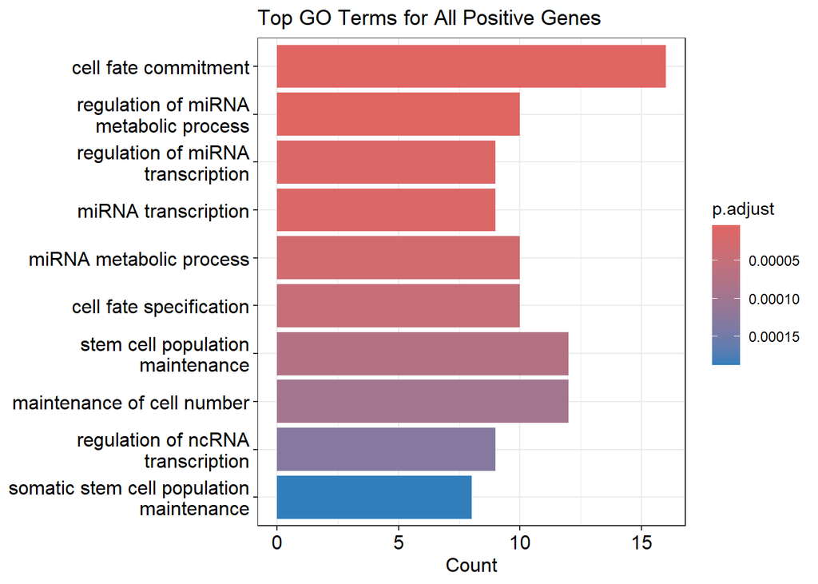

```r
# Bar plot of GO terms
barplot(ego_pos, showCategory=10) + ggtitle("Top GO Terms for All Positive Genes")
```

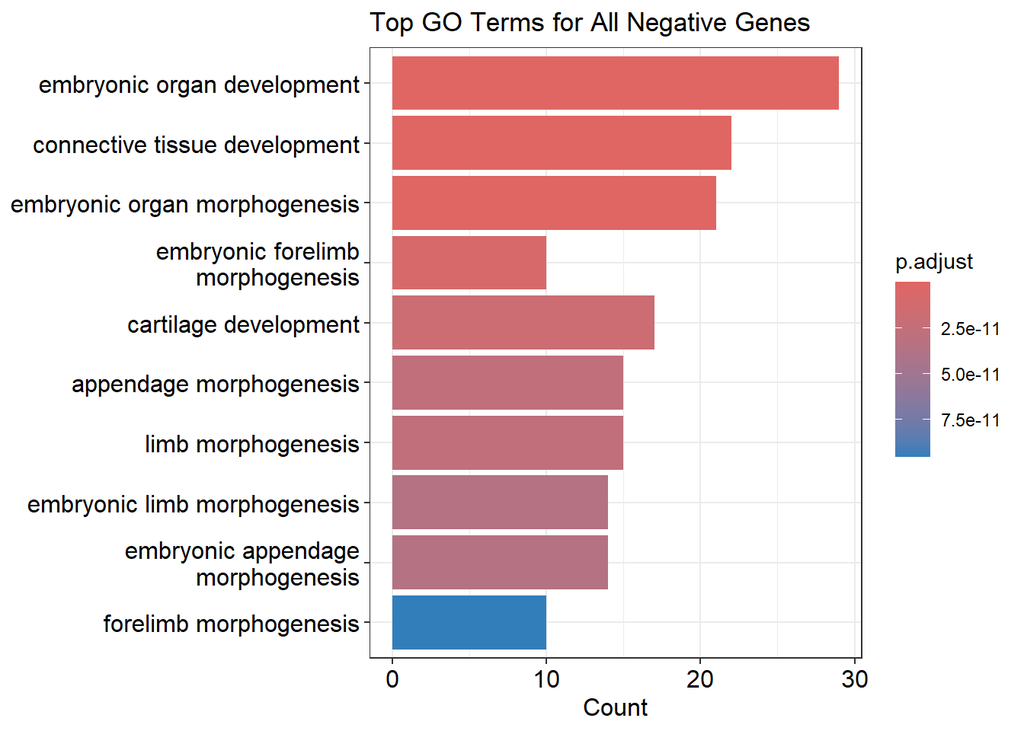

```r
barplot(ego_neg, showCategory=10) + ggtitle("Top GO Terms for All Negative Genes")
```

```r
# Extract ENSEMBL gene IDs or gene symbols
positive_genes <- as.character(top_ten_positive$gene_symbol_or_ORF)
negative_genes <- as.character(top_ten_negative$gene_symbol_or_ORF)
```

```r
# Convert gene symbols to ENTREZ IDs if necessary
positive_entrez <- bitr(positive_genes, fromType="SYMBOL", toType="ENTREZID", OrgDb="org.Hs.eg.db")
negative_entrez <- bitr(negative_genes, fromType="SYMBOL", toType="ENTREZID", OrgDb="org.Hs.eg.db")
# Perform GO enrichment analysis
ego_pos_ten <- enrichGO(gene          = positive_entrez$ENTREZID,
                    OrgDb         = org.Hs.eg.db,
                    keyType       = "ENTREZID",
                    ont           = "BP",  # Biological Process
                    pAdjustMethod = "holm",
                    qvalueCutoff  = 0.05)

ego_neg_ten <- enrichGO(gene          = negative_entrez$ENTREZID,
                    OrgDb         = org.Hs.eg.db,
                    keyType       = "ENTREZID",
                    ont           = "BP",
                    pAdjustMethod = "holm",
                    qvalueCutoff  = 0.05)
```

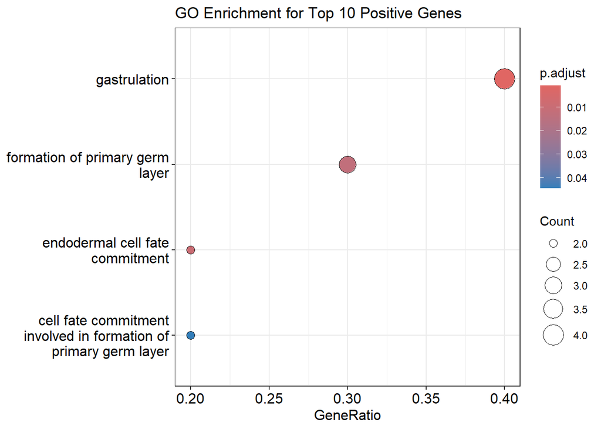

```r
# Visualize with a dotplot
dotplot(ego_pos_ten) + ggtitle("GO Enrichment for Top 10 Positive Genes")
```

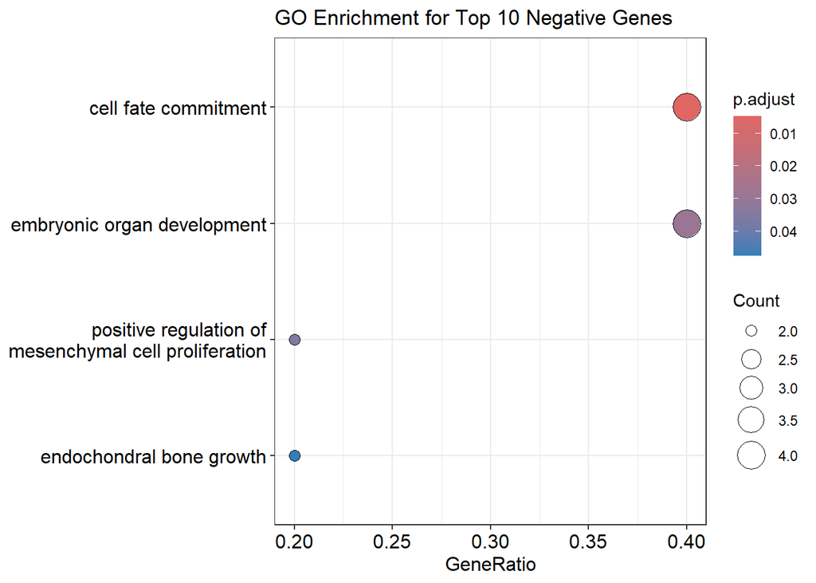

```r
dotplot(ego_neg_ten) + ggtitle("GO Enrichment for Top 10 Negative Genes")
```

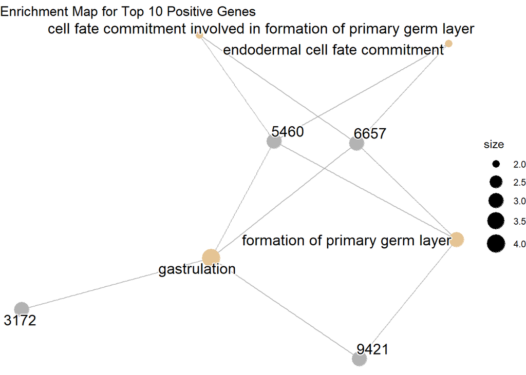

```r
# Visualize with a cnetplot
cnetplot(ego_pos_ten, foldChange=positive_entrez$log2FoldChange) + ggtitle("Enrichment Map for Top 10 Positive Genes")
```

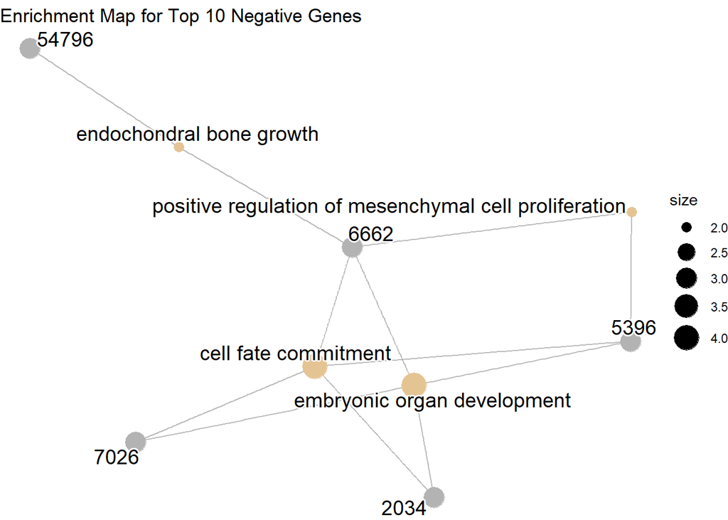

```r
cnetplot(ego_neg_ten, foldChange=negative_entrez$log2FoldChange) + ggtitle("Enrichment Map for Top 10 Negative Genes")
```

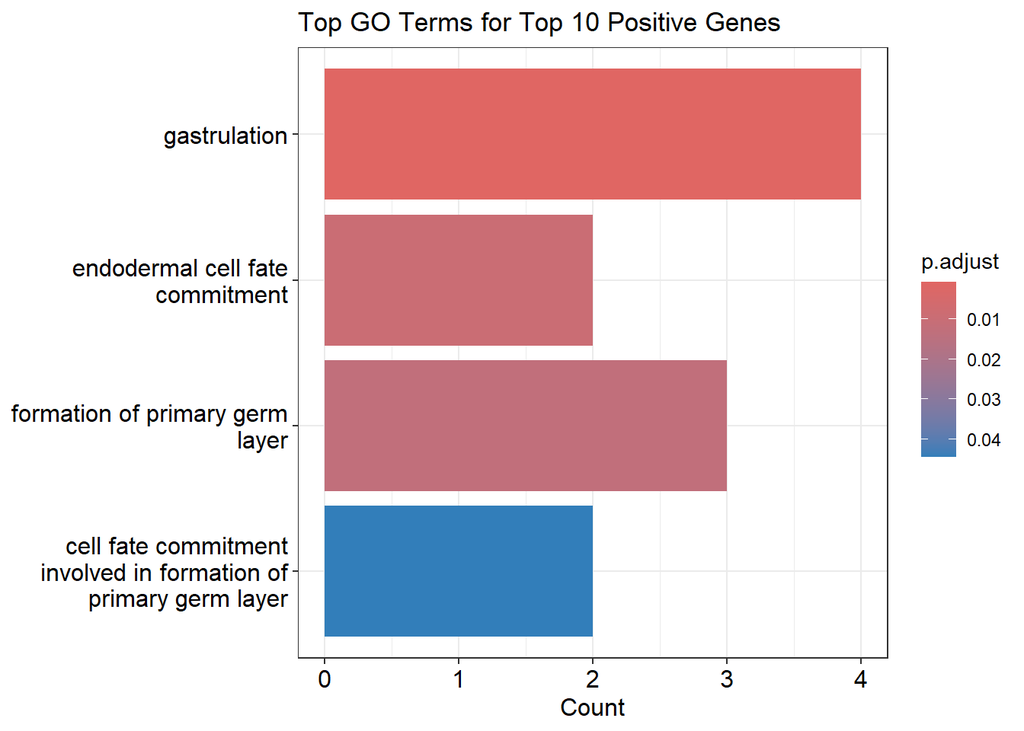

```r
# Bar plot of GO terms
barplot(ego_pos_ten, showCategory=10) + ggtitle("Top GO Terms for Top 10 Positive Genes")
```

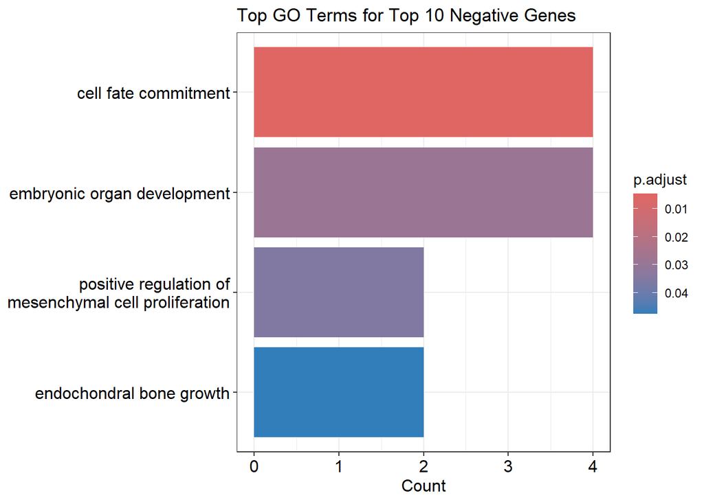

```r
barplot(ego_neg_ten, showCategory=10) + ggtitle("Top GO Terms for Top 10 Negative Genes")
```

```r
# Assuming 'ego_pos' is your enrichGO result for all positive genes
ego_pos_data <- as.data.frame(ego_pos)
revigo_input_pos <- ego_pos_data[, c("ID", "p.adjust")]

# Write this data to a CSV file for uploading to REVIGO
write.csv(revigo_input_pos, "revigo_input_pos.csv", row.names = FALSE)

# Assuming 'ego_pos_ten' is your enrichGO result for the top ten positive genes
ego_pos_ten_data <- as.data.frame(ego_pos_ten)
revigo_input_pos_ten <- ego_pos_ten_data[, c("ID", "p.adjust")]

# Write this data to a CSV file for uploading to REVIGO
write.csv(revigo_input_pos_ten, "revigo_input_pos_ten.csv", row.names = FALSE)

# Assuming 'ego_neg' is your enrichGO result for all negative genes
ego_neg_data <- as.data.frame(ego_neg)
revigo_input_neg <- ego_neg_data[, c("ID", "p.adjust")]

# Write this data to a CSV file for uploading to REVIGO
write.csv(revigo_input_neg, "revigo_input_neg.csv", row.names = FALSE)

# Assuming 'ego_neg_ten' is your enrichGO result for the top ten negative genes
ego_neg_ten_data <- as.data.frame(ego_neg_ten)
revigo_input_neg_ten <- ego_neg_ten_data[, c("ID", "p.adjust")]

# Write this data to a CSV file for uploading to REVIGO
write.csv(revigo_input_neg_ten, "revigo_input_neg_ten.csv", row.names = FALSE)
```

I screenshot the revigo reduced ontology results, and include them below.

**Revigo Treemap of all significant positive LFC genes, enriched in the 96 hour condition:**

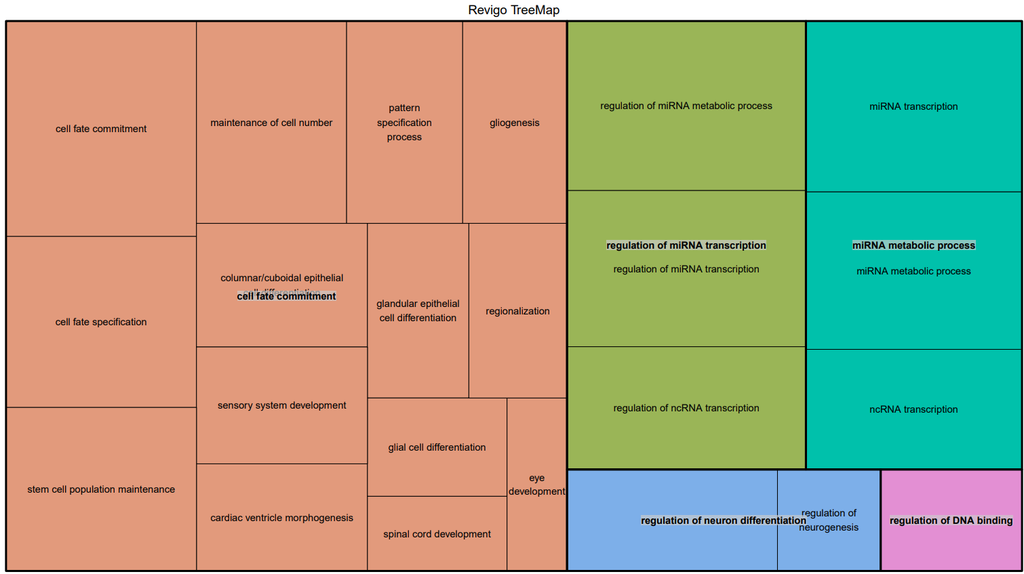

We’re seeing some intuitive GO categories, like stem cell population maintenance, but some unexpected ones, like cell fate commitment. Many GO terms indicate TFs that help “regulate” other processes. We don’t know whether this is positive or negative regulation, so Revigo in general may yield slightly more inscrutible results with Transcription Factors, given that their annotations in general are not as clear as, say, a protein-encoding gene.

**Revigo Treemap of all significant negative LFC genes, enriched in the untreated fibroblast condition:**

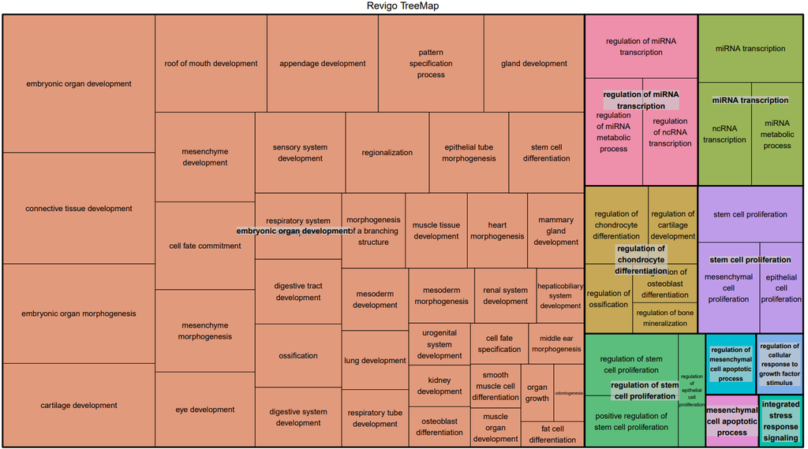

**Revigo Treemap of top ten most significant positive LFC OSKM-treatment-enriched genes:**

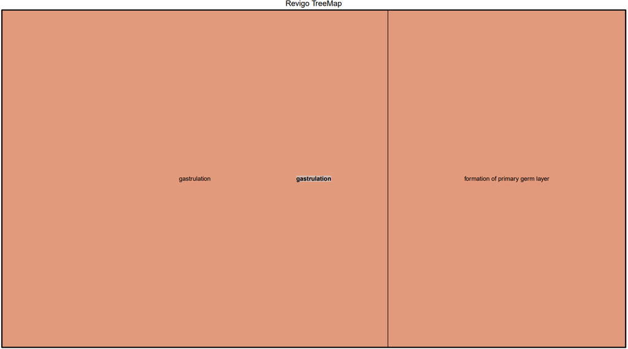

**Revigo Treemap of top ten most significant negative LFC untreated-fibroblast-enriched genes:**

[figure not shown]

This group is small enough that Revigo is not spectacularly enlightening, but the single largest GO term being downregulated is cell fate commitment, further in-keeping with our intuitions. Interestingly, however, “cell fate commitment” ontologies are listed very prominently amongst the top ten most significantly untreated-fibroblast-enriched genes. Yet it’s also a sizable ontology among the greater set of 96-hour-enriched genes. I can imagine, however, how cells becoming more stem-like could involve downregulating TFs that help preserve a current cell fate trajectory *and* upregulating TFs that have to be more active in steering a more embryonic cell towards an ultimate cell fate (and are thus markers of a more stem-like cell).

I manually pored through the different counts assays in my TF-filtered and unfiltered DESeq objects to ensure that counts were properly copied over.

1. The TF upreprogramome refers to transcription factors that have to be upregulated in the fibroblast for pluripotency induction.
2. The TF downreprogramome, with my data then, refers to fibroblast-enriched and specific transcriptional factors that have to be downregulated for pluripotency.

```r
library(readxl)
data <- read_excel("paper_log_fold_table.xlsx")
print(paste0("The length of my metadata table is ",nrow(data)))
```

```
## [1] "The length of my metadata table is 1636"
```

```r
# Assuming the columns are named exactly as "ensembl", "log2FoldChange", "padj", "Fibroblast_mean", and "ESC_mean" in the Excel file.
selected_data <- data %>%
  select(ensembl, log2FoldChange, padj, Fibroblast_mean, ESC_mean)
```

```r
head(selected_data)
```

```
## # A tibble: 6 × 5
##   ensembl         log2FoldChange      padj              Fibroblast_mean ESC_mean
##   <chr>           <chr>               <chr>                       <dbl>    <dbl>
## 1 ENSG00000253293 -13.505964410000001 5.81000000000000…           2487.        0
## 2 ENSG00000122592 -10.995031559999999 3.56000000000000…            437.        0
## 3 ENSG00000123388 -10.581269089999999 9.72000000000000…            329.        0
## 4 ENSG00000128710 -10.454612689999999 3.56000000000000…            299.        0
## 5 ENSG00000128709 -9.6350966870000008 2.19E-14                     169.        0
## 6 ENSG00000173917 -9.7098052930000005 3.78E-14                     180.        0
```

```r
print(paste0("The length of my metadata table is ",nrow(selected_data)))
```

```
## [1] "The length of my metadata table is 1636"
```

Going off of the criteria defined in the paper that evaluates log2fold change in expression differences between a human ESCs and the pre-OSKM fibroblast samples that I am analyzing, as well as the mean gene counts for every TF gene from the fibroblast and hESC samples, I subset the data into the upreprogramome, downreprogramome, and unresponsome. These, respectively, are each a list of transcription factors that have to be upregulated, downregulated, or unaffected by Yamanaka transduction for their transcriptome to resemble an iPSC rather than a fibroblast.

```r
# Assuming selected_data is already loaded and is a dataframe

# Load the necessary library
library(dplyr)

# Ensure that log2FoldChange and padj are numeric
selected_data <- selected_data %>%
  mutate(
    log2FoldChange = as.numeric(as.character(log2FoldChange)),
    padj = as.numeric(as.character(padj))
  ) %>%
  # Handle NAs that may have been introduced by coercion
  filter(!is.na(log2FoldChange) & !is.na(padj))
# Define the thresholds
active_threshold <- 50
fold_change_threshold <- 2
q_value_threshold <- 0.01

upreprogramome <- selected_data %>%
  filter(ESC_mean > active_threshold, log2FoldChange > fold_change_threshold,
         padj < q_value_threshold)

downreprogramome <- selected_data %>%
  filter(Fibroblast_mean > active_threshold, log2FoldChange < -fold_change_threshold,
         padj < q_value_threshold)


cat("Upreprogramome:", nrow(upreprogramome), "\n")
```

```
## Upreprogramome: 210
```

```r
cat("Downreprogramome:", nrow(downreprogramome), "\n")
```

```
## Downreprogramome: 191
```

A fairly in-depth GO analysis of these different ’omes has already been done in the original paper. I am more interested, however, in how exactly the GO composition shifts post-induction. Do different types of TFs shift toward stemness at around the same time?

```r
library(fgsea)


upreprogramome_genes <- upreprogramome$ensembl
downreprogramome_genes <- downreprogramome$ensembl


# Create a list of gene sets for GSEA
gene_sets <- list(
  Upreprogramome = upreprogramome_genes,
  Downreprogramome = downreprogramome_genes
)
```

```r
# Extract all significant genes with positive and negative log2FoldChanges
significant_up_genes <- shrunk_tf_results_df %>%
                      filter(padj < 0.05 & log2FoldChange > 0)

significant_down_genes <- shrunk_tf_results_df %>%
                         filter(padj < 0.05 & log2FoldChange < 0)
```

```r
head(significant_up_genes)
```

```
##                   baseMean log2FoldChange     lfcSE     stat       pvalue
## ENSG00000204531 43317.7638      11.846772 0.2708175 43.74449 0.000000e+00
## ENSG00000136826 21747.7766       5.955659 0.2825502 21.07823 1.260038e-98
## ENSG00000181449 11953.2175      13.262626 0.6390889 20.75240 1.166311e-95
## ENSG00000185507  1337.8386       3.694227 0.1929881 19.14225 1.123219e-81
## ENSG00000188313  2633.6267       2.902431 0.1796829 16.15308 1.080328e-58
## ENSG00000151090   239.2806       5.296590 0.3358137 15.77240 4.818090e-56
##                         padj gene_symbol_or_ORF          ORF
## ENSG00000204531 1.950539e-96             POU5F1 NM_001173531
## ENSG00000136826 1.950539e-95               KLF4 NM_001314052
## ENSG00000181449 1.804283e-92               SOX2    NM_003106
## ENSG00000185507 1.736496e-78               IRF7    NM_001572
## ENSG00000188313 1.669107e-55             PLSCR1 NM_001363872
## ENSG00000151090 7.439131e-53               THRB    NM_000461
```

```r
head(upreprogramome_genes)
```

```
## [1] "ENSG00000157554" "ENSG00000113430" "ENSG00000168772" "ENSG00000180535"
## [5] "ENSG00000166268" "ENSG00000164749"
```

```r
# Assuming shrunk_tf_results_df is your DESeq2 results dataframe and upreprogramome_genes is a vector of gene IDs
# First, ensure that your gene IDs in upreprogramome_genes do not have version numbers if they are present in your shrunk_tf_results_df
upreprogramome_genes <- sub("\\..*", "", upreprogramome_genes)

# Now, subset your shrunk_tf_results_df to include only the rows with gene IDs that match the upreprogramome_genes
upreprogramome_genes <- shrunk_tf_results_df[rownames(shrunk_tf_results_df) %in% upreprogramome_genes, ]

# Assuming shrunk_tf_results_df is your DESeq2 results dataframe and upreprogramome_genes is a vector of gene IDs
# First, ensure that your gene IDs in upreprogramome_genes do not have version numbers if they are present in your shrunk_tf_results_df
downreprogramome_genes <- sub("\\..*", "", downreprogramome_genes)

# Now, subset your shrunk_tf_results_df to include only the rows with gene IDs that match the upreprogramome_genes
downreprogramome_genes <- shrunk_tf_results_df[rownames(shrunk_tf_results_df) %in% downreprogramome_genes, ]
```

```r
# Extract gene IDs as vectors from the filtered dataframes
significant_up_gene_ensembl <- rownames(significant_up_genes)
significant_down_gene_ensembl <- rownames(significant_down_genes)

upreprogramome_gene_ensembl <- rownames(upreprogramome_genes)
downreprogramome_gene_ensembl <- rownames(downreprogramome_genes)
```

```r
# Assuming that upreprogramome_genes and downreprogramome_genes are correctly formatted as vectors
# Now the lists for the Venn diagram are set up correctly:
significant_up_gene_ensembl <- as.character(significant_up_gene_ensembl)
significant_down_gene_ensembl <- as.character(significant_down_gene_ensembl)

upreprogramome_gene_ensembl <- as.character(upreprogramome_gene_ensembl)
downreprogramome_gene_ensembl <- as.character(downreprogramome_gene_ensembl)
```

```r
library(VennDiagram)
```

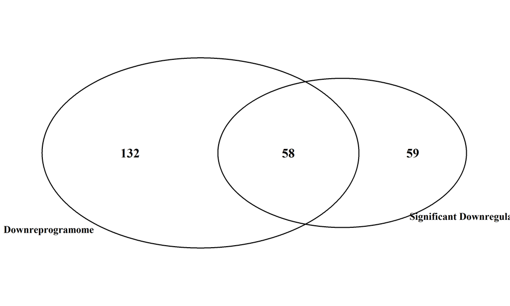

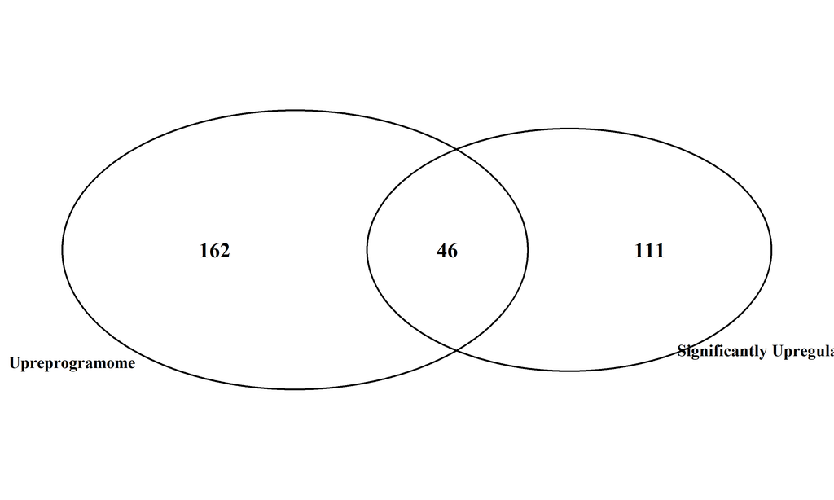

```r
library(grid)

# Define dimensions in inches
width_in_inches <- 10
height_in_inches <- 6

# Create Venn Diagrams and save as PNG files
venn.plot.up <- venn.diagram(
  x = list(
    Significant_Up = significant_up_gene_ensembl,
    Upreprogramome = upreprogramome_gene_ensembl
  ),
  category.names = c("Significantly Upregulated", "Upreprogramome"),
  filename = "venn_diagram_up.png",  # Saving as PNG file
  output = TRUE,
  imagetype = "png",
  height = height_in_inches,  # height in inches
  width = width_in_inches,    # width in inches
  resolution = 300,
  compression = "lzw",
  units = "in",  # specify units
  lwd = 2,       # line width
  cex = 1.5,     # font size scaling factor
  fontface = "bold",  # font style
  cat.cex = 1.2,      # category label scaling factor
  cat.fontface = "bold",  # category label font style
  cat.default.pos = "outer",  # category label position
  cat.dist = 0.05,   # distance for category labels from the center of the diagram
  margin = 0.05      # margin around the plot
)

venn.plot.down <- venn.diagram(
  x = list(
    Significant_Down = significant_down_gene_ensembl,
    Downreprogramome = downreprogramome_gene_ensembl
  ),
  category.names = c("Significant Downregulated", "Downreprogramome"),
  filename = "venn_diagram_down.png",  # Saving as PNG file
  output = TRUE,
  imagetype = "png",
  height = height_in_inches,
  width = width_in_inches,
  resolution = 300,
  compression = "lzw",
  units = "in",
  lwd = 2,
  cex = 1.5,
  fontface = "bold",
  cat.cex = 1.2,
  cat.fontface = "bold",
  cat.default.pos = "outer",
  cat.dist = 0.05,
  margin = 0.05
)
```

I apologize for these clipping off the screen to the right. I was having enormous difficulty getting venn diagrams to size the window dynamically to the diagram.

```r
# Load the required library
library(fgsea)

# Prepare your ranked list of genes
# This example assumes `shrunk_tf_results_df` is your dataframe from DESeq2 results
# and it's sorted from most upregulated to most downregulated based on log2FoldChange
ranked_list <- with(shrunk_tf_results_df, setNames(-log10(padj) * sign(log2FoldChange), shrunk_tf_results_df$gene_symbol_or_ORF))
```

```r
# Prepare gene sets from the filtered dataframes
gene_sets <- list(
  Upreprogramome = upreprogramome_genes$gene_symbol_or_ORF,
  Downreprogramome = downreprogramome_genes$gene_symbol_or_ORF
)

# Run GSEA for upregulated genes
# 'scoreType = "pos"' focuses the analysis on the positive side of the ranked list
gsea_results_up <- fgsea(pathways = gene_sets["Upreprogramome"],
                         stats = ranked_list,
                         scoreType = "pos",
                         minSize = 15,    # Minimum size of gene set to consider
                         maxSize = 500,   # Maximum size of gene set to consider
                         nperm = 10000)   # Number of permutations for estimation
# Run GSEA for downregulated genes
# 'scoreType = "neg"' focuses the analysis on the negative side of the ranked list
gsea_results_down <- fgsea(pathways = gene_sets["Downreprogramome"],
                           stats = ranked_list,
                           scoreType = "neg",
                           minSize = 15,
                           maxSize = 500,
                           nperm = 10000)
# Print the GSEA results to examine the outputs
print(gsea_results_up)
```

```
##           pathway      pval      padj        ES      NES nMoreExtreme  size
##            <char>     <num>     <num>     <num>    <num>        <num> <int>
## 1: Upreprogramome 9.999e-05 9.999e-05 0.8325559 1.727795            0   208
##     leadingEdge
##          <list>
## 1: POU5F1, ....
```

```r
print(gsea_results_down)
```

```
##             pathway       pval       padj         ES       NES nMoreExtreme
##              <char>      <num>      <num>      <num>     <num>        <num>
## 1: Downreprogramome 0.00239976 0.00239976 -0.6859845 -2.081626           23
##     size  leadingEdge
##    <int>       <list>
## 1:   190 NR2F2, E....
```

```r
# Extract the most significant results
most_significant_up <- gsea_results_up[which.min(gsea_results_up$pval), ]
most_significant_down <- gsea_results_down[which.min(gsea_results_down$pval), ]

# Confirm the pathway name or index
print(most_significant_up$pathway)
```

```
## [1] "Upreprogramome"
```

```r
print(most_significant_down$pathway)
```

```
## [1] "Downreprogramome"
```

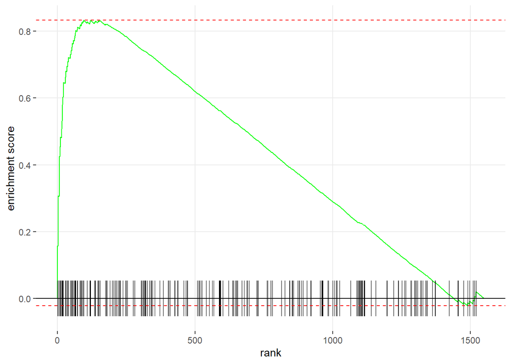

```r
# Visualization of the most significant GSEA results
# Ensure the pathway is selected correctly

# Since 'most_significant_up$pathway' and 'most_significant_down$pathway' return the names directly:
plotEnrichment(pathway = gene_sets[["Upreprogramome"]], ranked_list)
```

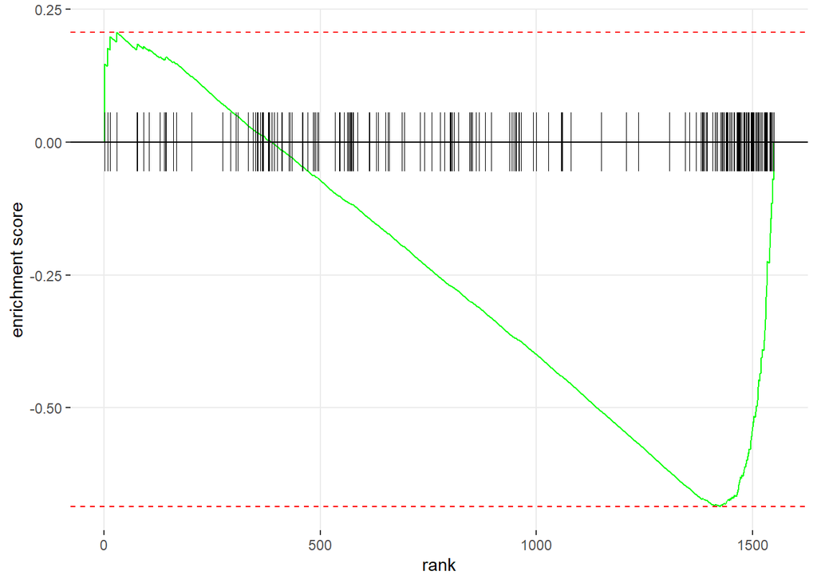

```r
# Add a title manually using the title() function in base R


plotEnrichment(pathway = gene_sets[["Downreprogramome"]], ranked_list)
```

```r
# Add a title manually using the title() function in base R
```

These plots extend over my transcription factors ranked from left to right by most upregulated to most downregulated.

The first of these two enrichment plots is for the upreprogramome across my TFs, and the second is for the downreprogramome.